# Mid-term Project – Aiding Africa

Shu Su & Hanlin Wang

5/12/2018

## **Aiding Africa Project Introduction**

The American Red Cross and the International Federation of Red Cross(IFRC) have decided to proactively develop aid disbursement plans for Africa. The raw data in the tables includes the capacity and speed of transportations, African destinations, city transport pairs, transport modes, distances and cost, aid requirements, air and truck restrictions. After drawing a “networking map” showing the different routes workers and supplies, we develop three possible plans under different scenarios.

## **Networking Map of Transportation Routes**

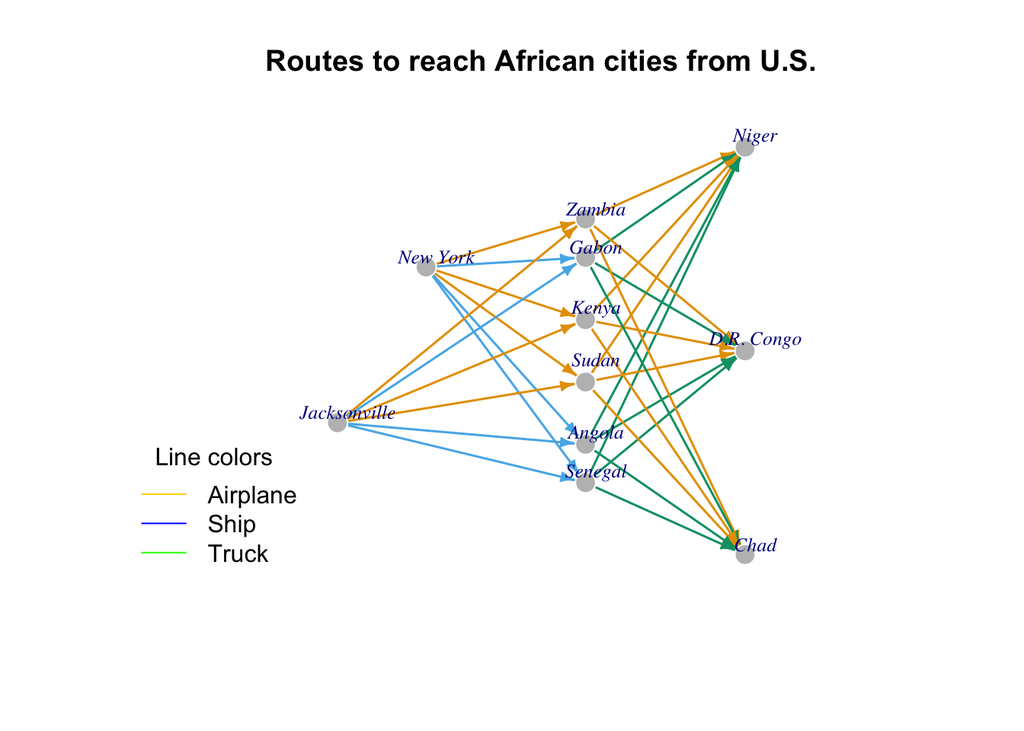

This graph illustrates the possible routes to reach each nine African cities from two American cities. There are three types of transportation. Gold lines are Airplane routes, blue lines are Shipping routes and green lines are Truck routes. Starting from New York or Jacksonville, we have six transhipping countries: *Zambia, Gabon, Kenya, Sudan, Angola and Senegal*. Aids are distributed to the three strategic countries: *Niger, D.R.Congo and Chad* from the six transhipping countries.